# Exploring the role of glucocorticoids in the hippocampus under stress conditions and circadian influences – A recreation of the original analysis by Mifsud et al. (2021)

Group 1 – Laura Fusi, Vanessa Löw, Jan Matthias

2023-07-12

# Introduction:

Glucocorticoid hormones (GC) play an important role in the central nervous system during normal daily activities as well as in stressful situations. Conversely, mental disorders related to stress like Major depressive disorder (MDD) and post-traumatic stress disorder (PTSD) are associated with impaired GC function and secretion.

The secretion of GC is controlled by the circadian rhythm, with the highest concentration accompanying the beginning of the active phase, and stressful events influencing this rhythmic release.

GCs bind to both mineralocorticoid and glucocorticoid receptors (MR and GR, respectively), both of which have different functions and localizations in the brain. Nevertheless, both MRs and GRs are co-localized in the neurons of the hippocampus, where, once bound by a GC, they act as ligand-dependent transcription factors.

The GR and MR in the hippocampus are hypothesized to play a distinct role in circadian and stress-related physiology as well as cognition and behavior, but the molecular mechanisms and particularly which genes are regulated by either of the two receptors is still unclear. To identify the MR- and GR- regulated genes, a genome-wide study of the interaction between GR and DNA is needed. Furthermore, to establish the complete implications of GC signaling in the hippocampus, the identity of all MR- and GR-targeted genes ought to be determined (Mifsud et al., 2021).

In this study therefore, the team measured the interaction of MR and GR with the rat’s hippocampal genome under baseline conditions (early morning (BLAM) and late afternoon (BLPM)) as well as after acute stress exposure in the form of a forced swimming test (FS30)).

The animals were killed right after stress exposure or according to the circadian schedule of the group they belonged to, and their hippocampal tissue was removed. Thus, it is important to note that for each condition (BLAM, FS30, BLPM) in each receptor group (MR, GR), a different animal was used. After collecting samples, ChIP-seq and RNA analyses were performed. For this analysis, we are focusing on the ChIP-seq data provided.

Our goal for this project was to recreate some of the analyses done, which included the plotting of the average number of significant peaks for each receptor, as well as Upset Plots to depict overlaps of MR and GR peaks across samples and conditions, which in the paper was done using Venn Diagrams. Furthermore, we did a differential binding analysis but applied clustering instead of the simpler Overlaps method and, on the basis of the clusters, a GO (Gene Ontology) biological analysis to investigate underlying biological processes.

# Average number of significant peaks

## Methods

To get an overview of the significant peaks in each condition per receptor and to get familiar with the dataset, we recreated figure 1a of the paper. This figure depicts the average number of significant peaks under each of the three conditions. Because of the relatively small number of peaks, and because the data set had been filtered for significance beforehand, a further filtering of significant peaks was not necessary. Thus the significant peaks were directly combined into data frames and means plotted using ggplot.

```r
suppressPackageStartupMessages({
library(GenomicRanges)
library(ggplot2)
library(dplyr)
library(car)
library(epiwraps)
library(rtracklayer)
})
```

### Load data (load each dataset of each animal separately):

```r
#2 Groups (MR, GR), 3 conditions per group (n=4 animals per condition):

#MR
##BLAM

peakfilesBLAM_MR <- list.files("/Users/vanessaloew/Documents/GitHub/bioinformatics_final_project/NarrowPeaks_renamed ",pattern = "BLAM_MR", full.name=TRUE)
variableNames <- gsub("\\.narrowPeak","",basename(peakfilesBLAM_MR))

for (i in seq_along(peakfilesBLAM_MR)) {
  gr <- rtracklayer::import(peakfilesBLAM_MR[i], format = "narrowPeak")
  assign(variableNames[i], gr)
}

##FS30

peakfilesFS30_MR <- list.files("/Users/vanessaloew/Documents/GitHub/bioinformatics_final_project/NarrowPeaks_renamed ",pattern = "FS30_MR", full.name=TRUE)
variableNames <- gsub("\\.narrowPeak","",basename(peakfilesFS30_MR))

for (i in seq_along(peakfilesFS30_MR)) {
  gr <- rtracklayer::import(peakfilesFS30_MR[i], format = "narrowPeak")
  assign(variableNames[i], gr)
}

##BLPM

peakfilesBLPM_MR <- list.files("/Users/vanessaloew/Documents/GitHub/bioinformatics_final_project/NarrowPeaks_renamed ",pattern = "BLPM_MR", full.name=TRUE)
variableNames <- gsub("\\.narrowPeak","",basename(peakfilesBLPM_MR))

for (i in seq_along(peakfilesBLPM_MR)) {
  gr <- rtracklayer::import(peakfilesBLPM_MR[i], format = "narrowPeak")
  assign(variableNames[i], gr)
}


#GR
##BLAM

peakfilesBLAM_GR <- list.files("/Users/vanessaloew/Documents/GitHub/bioinformatics_final_project/NarrowPeaks_renamed ",pattern = "BLAM_GR", full.name=TRUE)
variableNames <- gsub("\\.narrowPeak","",basename(peakfilesBLAM_GR))

for (i in seq_along(peakfilesBLAM_GR)) {
  gr <- rtracklayer::import(peakfilesBLAM_GR[i], format = "narrowPeak")
  assign(variableNames[i], gr)
}

##FS30

peakfilesFS30_GR <- list.files("/Users/vanessaloew/Documents/GitHub/bioinformatics_final_project/NarrowPeaks_renamed ",pattern = "FS30_GR", full.name=TRUE)
variableNames <- gsub("\\.narrowPeak","",basename(peakfilesFS30_GR))

for (i in seq_along(peakfilesFS30_GR)) {
  gr <- rtracklayer::import(peakfilesFS30_GR[i], format = "narrowPeak")
  assign(variableNames[i], gr)
}

##BLPM

peakfilesBLPM_GR <- list.files("/Users/vanessaloew/Documents/GitHub/bioinformatics_final_project/NarrowPeaks_renamed ",pattern = "BLPM_GR", full.name=TRUE)
variableNames <- gsub("\\.narrowPeak","",basename(peakfilesBLPM_GR))

for (i in seq_along(peakfilesBLPM_GR)) {
  gr <- rtracklayer::import(peakfilesBLPM_GR[i], format = "narrowPeak")
  assign(variableNames[i], gr)
}
```

### Combine single peak data into data frames (one per condition & receptor = 6 data frames)

```r
#BLAM_MR
BLAM_MR <- rbind(length(BLAM_MR_1), length(BLAM_MR_2), length(BLAM_MR_3), length(BLAM_MR_4))

#FS30_MR
FS30_MR <- rbind(length(FS30_MR_1), length(FS30_MR_2), length(FS30_MR_3), length(FS30_MR_4))

#BLPM_MR
BLPM_MR <- rbind(length(BLPM_MR_1), length(BLPM_MR_2), length(BLPM_MR_3), length(BLPM_MR_4))



#BLAM_GR
BLAM_GR <- rbind(length(BLAM_GR_1), length(BLAM_GR_2), length(BLAM_GR_3), length(BLAM_GR_4))

#FS30_GR
FS30_GR <- rbind(length(FS30_GR_1), length(FS30_GR_2), length(FS30_GR_3), length(FS30_GR_4))

#BLPM_GR
BLPM_GR <- rbind(length(BLPM_GR_1), length(BLPM_GR_2), length(BLPM_GR_3), length(BLPM_GR_4))
```

### Combine peak data for conditions into one data frame for each receptor (2 data frames)

```r
MR <- rbind(BLAM_MR, FS30_MR, BLPM_MR)
MR <- as.data.frame(MR)
colnames(MR)[1] <- "Peaks"
#add groups
MR$Group <- c(rep("BLAM", 4), rep("FS30", 4), rep("BLPM", 4))

GR <- rbind(BLAM_GR, FS30_GR, BLPM_GR)
GR <- as.data.frame(GR)
colnames(GR)[1] <- "Peaks"
#add groups
GR$Group <- c(rep("BLAM", 4), rep("FS30", 4), rep("BLPM", 4))
```

### Plot the two groups into one data frame/graph

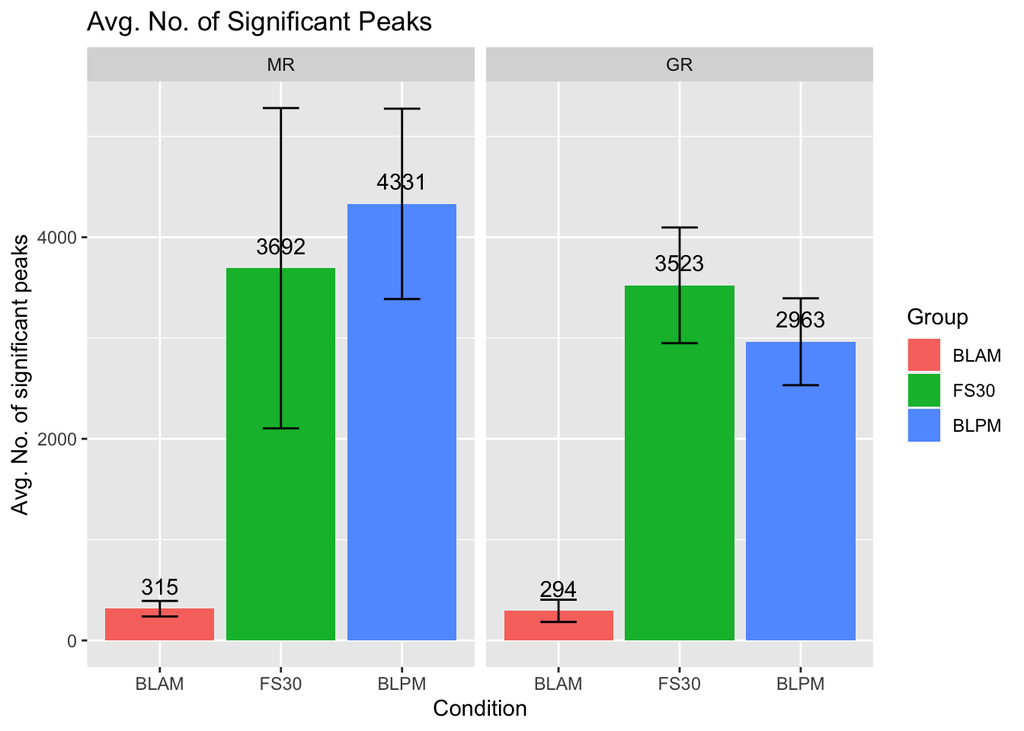

```r
#add column to indicate receptor
MR$Receptor <- c(rep("MR"))
GR$Receptor <- c(rep("GR"))

#combine data frames
MRGR<- rbind(MR, GR)

#reorder conditions
#create desired order
cOrder <- c("BLAM", "FS30", "BLPM")
#transform to factors
MRGR$Group <- factor(MRGR$Group, levels = cOrder)

#reorder receptor groups
##create desired order
rOrder <- c("MR", "GR")
##transform to factors
MRGR$Receptor <- factor(MRGR$Receptor, levels = rOrder)


#plot MR/GR
MRGRplot <- ggplot(MRGR, aes(x = Group, y = Peaks, fill = Group)) + stat_summary(fun = mean, geom = "bar") + stat_summary(fun.data = mean_cl_normal, geom = "errorbar", width = 0.3) + labs(x ="Condition", y = "Avg. No. of significant peaks", title = "Avg. No. of Significant Peaks" ) + facet_wrap(~Receptor)

#calulate mean values to add as labels
mean_values <- MRGR %>% group_by(Receptor, Group) %>% summarise(mean_Peaks = mean(Peaks))
mean_values$mean_Peaks <- round(mean_values$mean_Peaks)

MRGRplot + geom_text(data = mean_values, aes(x = Group, y = mean_Peaks, label = mean_Peaks, group = Group), position = position_dodge(width = 0.9), vjust = -0.9)
```

## Results

The resulting bar chart looked different to the one in the paper: Lower values can be seen for the baseline condition (BLAM) of the MR in the reproduced figure compared to the original. When looking at the absolute numbers of peaks for each BLAM MR sample, the results from the paper do not fully make sense, as the number plotted as a mean of the four samples (637) is higher than any absolute number in the BLAM_MR data frame. We were not able to find a reason for this unfortunately. The rest of the conditions for both receptors showed lower numbers in the graph from the paper compared to our recreation. This is most likely due to the fact that we did not filter the peaks for duplicates across conditions, while in the paper, only the unique peaks were plotted.

Still, the resulting relative differences between conditions are the similar to the depiction in the paper: When looking at the BLAM condition, one can observe only very little binding of MR and GR. A strong increase was visible when the animals were stressed (FS30), with the binding of MR being slightly higher than that of GR. On the other hand, in the BLPM group, more MR was bound compared to binding of GR.